# Lab 5

## Part Four: New data

```python
df_new = pd.read_csv("https://www.dropbox.com/s/sky86agc4s8c6qe/insurance_costs_2.csv?dl=1")
df_new
```

|  | age | sex | bmi | smoker | region | charges |
| --- | --- | --- | --- | --- | --- | --- |
| 0 | 23 | male | 34.400 | no | southwest | 1826.84300 |
| 1 | 56 | male | 40.300 | no | southwest | 10602.38500 |
| 2 | 18 | male | 34.100 | no | southeast | 1137.01100 |
| 3 | 63 | female | 23.085 | no | northeast | 14451.83515 |
| 4 | 63 | male | 28.310 | no | northwest | 13770.09790 |
| ... | ... | ... | ... | ... | ... | ... |
| 138 | 19 | male | 34.900 | yes | southwest | 34828.65400 |
| 139 | 45 | male | 30.360 | yes | southeast | 62592.87309 |
| 140 | 43 | male | 27.800 | yes | southwest | 37829.72420 |
| 141 | 24 | female | 27.720 | no | southeast | 2464.61880 |
| 142 | 18 | male | 53.130 | no | southeast | 1163.46270 |

143 rows × 6 columns

Data CLeaning

```python
df_new = df.dropna() # no null values in the dataset
#df.info() #df = pd.get_dummies(df, columns=['sex', 'smoker'], drop_first=True)
df_dummies_new = pd.get_dummies(df, columns=['sex', 'smoker', 'region'], drop_first=True)
#converted into dummies for numeric plotting
#df_dummies_new
#renamed some columns
df_dummies_new = df_dummies_new.rename(columns={'sex_male': 'Male', 'smoker_yes': 'Smokes',})
df_dummies_new.head()

# X_tes and y_test from new dattaframe:
X_test = df_dummies_new[['age']]
y_test = df_dummies_new['charges']
```

### Age as predictor

```python
results_df_new = pd.DataFrame(columns=['Model', 'MSE', 'Interpretation']) #empty dataframe to store MSEs

X = df_dummies[['age']]
y = df_dummies['charges']

pipeline = Pipeline([
    ('scaler', StandardScaler()),   # scales features
    ('regressor', LinearRegression())  # linear model
])

pipeline.fit(X, y)
y_pred = pipeline.predict(X_test)

mse = mean_squared_error(y_test, y_pred)

print(f"MSE: {mse:.2f}")
results_df_new.loc[len(results_df)] = ['age', mse, 'pretty high error']
```

```
MSE: 126739267.91
```

### Age and BMI as predictor

```python
X_test = df_dummies_new[['age', 'bmi']]
y_test = df_dummies_new['charges']

X = df_dummies[['age', 'bmi']]
y = df_dummies['charges']

pipeline = Pipeline([
    ('scaler', StandardScaler()),   # scales features
    ('regressor', LinearRegression())  # linear model
])
df_new
pipeline.fit(X, y)
y_pred = pipeline.predict(X_test)

mse = mean_squared_error(y_test, y_pred)

print(f"MSE: {mse:.2f}")

results_df_new.loc[len(results_df_new)] = ['age and BMI', mse, 'slightly lower']
```

```
MSE: 123792439.58
```

### Age, BMI and Smoking as predictors

```python
X_test = df_dummies_new[['age', 'bmi', 'Smokes']]
y_test = df_dummies_new['charges']
X = df_dummies[['age', 'bmi', 'Smokes']]
y = df_dummies['charges']

pipeline = Pipeline([
    ('scaler', StandardScaler()),   # scales features
    ('regressor', LinearRegression())  # linear model
])

pipeline.fit(X, y)

y_pred = pipeline.predict(X_test)

mse = mean_squared_error(y_test, y_pred)

print(f"MSE: {mse:.2f}")
results_df_new.loc[len(results_df_new)] = ['Age, BMI and Smokes', mse, 'much lower, better']
```

```
MSE: 30812111.94
```

### Age, BMI, (Age + BMI)* Smoker

```python
# Preparing the data:
df_dummies.eval('age_smoker = age * Smokes', inplace=True)
df_dummies.eval('bmi_smoker = bmi * Smokes', inplace=True)
df_dummies
df_dummies_new.eval('age_smoker = age * Smokes', inplace=True)
df_dummies_new.eval('bmi_smoker = bmi * Smokes', inplace=True)
df_dummies
```

|  | age | bmi | charges | Male | Smokes | region_northwest | region_southeast | region_southwest | age_squared | age_smoker | bmi_smoker |
| --- | --- | --- | --- | --- | --- | --- | --- | --- | --- | --- | --- |
| 0 | 19 | 27.900 | 16884.92400 | False | True | False | False | True | 361 | 19 | 27.90 |
| 1 | 33 | 22.705 | 21984.47061 | True | False | True | False | False | 1089 | 0 | 0.00 |
| 2 | 32 | 28.880 | 3866.85520 | True | False | True | False | False | 1024 | 0 | 0.00 |
| 3 | 31 | 25.740 | 3756.62160 | False | False | False | True | False | 961 | 0 | 0.00 |
| 4 | 60 | 25.840 | 28923.13692 | False | False | True | False | False | 3600 | 0 | 0.00 |
| ... | ... | ... | ... | ... | ... | ... | ... | ... | ... | ... | ... |
| 426 | 23 | 33.400 | 10795.93733 | False | False | False | False | True | 529 | 0 | 0.00 |
| 427 | 18 | 31.920 | 2205.98080 | False | False | False | False | False | 324 | 0 | 0.00 |
| 428 | 18 | 36.850 | 1629.83350 | False | False | False | True | False | 324 | 0 | 0.00 |
| 429 | 21 | 25.800 | 2007.94500 | False | False | False | False | True | 441 | 0 | 0.00 |
| 430 | 61 | 29.070 | 29141.36030 | False | True | True | False | False | 3721 | 61 | 29.07 |

431 rows × 11 columns

```python
X_train = df_dummies[['age', 'bmi', 'age_smoker', 'bmi_smoker']]
y_train = df_dummies['charges']

X_test = df_dummies_new[['age', 'bmi', 'age_smoker', 'bmi_smoker']]
y_test = df_dummies_new['charges']

pipeline = Pipeline(
    [ ('scaler', StandardScaler()),
    ('regressor', LinearRegression())]
)

pipeline.fit(X_train, y_train)

y_pred = pipeline.predict(X_test)

mse = mean_squared_error(y_test, y_pred)

print(f"MSE : {mse:.2f}")
results_df_new.loc[len(df_dummies_new)] = ['Age, BMI, (Age + BMI)* Smoker', mse, 'even lower, best so far']
```

```
MSE : 20773858.81
```

Comparison of MSEs

```python
results_df_new
```

|  | Model | MSE | Interpretation |
| --- | --- | --- | --- |
| 5 | age | 1.267393e+08 | pretty high error |
| 1 | age and BMI | 1.237924e+08 | slightly lower |
| 2 | Age, BMI and Smokes | 3.081211e+07 | much lower, better |
| 431 | Age, BMI, (Age + BMI)* Smoker | 2.077386e+07 | even lower, best so far |

### Age, BMI, Smoker, (age + bmi)* smoker

```python
X_train = df_dummies[['age', 'bmi', 'Smokes', 'age_smoker', 'bmi_smoker' ]]
y_train = df_dummies['charges']

X_test = df_dummies_new[['age', 'bmi', 'Smokes', 'age_smoker', 'bmi_smoker' ]]
y_test = df_dummies_new['charges']

pipeline = Pipeline([
    ('scaler', StandardScaler()),
    ('regressor', LinearRegression())
])

pipeline.fit(X_train, y_train)

y_pred = pipeline.predict(X_test)

mse = mean_squared_error(y_test, y_pred)
# residuals for best model--------
residuals = y_test - y_pred
print(f"MSE : {mse:.2f}")
results_df_new.loc[len(results_df_new)] = ['Age, BMI, Smoker, (age + bmi)* smoker',mse, 'lowest, best model']
results_df_new.reset_index(drop=True)
df_dummies_new.head()
```

```
MSE : 18674284.77
```

|  | age | bmi | charges | Male | Smokes | region_northwest | region_southeast | region_southwest | age_smoker | bmi_smoker |
| --- | --- | --- | --- | --- | --- | --- | --- | --- | --- | --- |
| 0 | 19 | 27.900 | 16884.92400 | False | True | False | False | True | 19 | 27.9 |
| 1 | 33 | 22.705 | 21984.47061 | True | False | True | False | False | 0 | 0.0 |
| 2 | 32 | 28.880 | 3866.85520 | True | False | True | False | False | 0 | 0.0 |
| 3 | 31 | 25.740 | 3756.62160 | False | False | False | True | False | 0 | 0.0 |
| 4 | 60 | 25.840 | 28923.13692 | False | False | True | False | False | 0 | 0.0 |

Based on the MSE for all the models above, model #5 is the best with lowest MSE of 18674280

### Plotting for best model for part 4

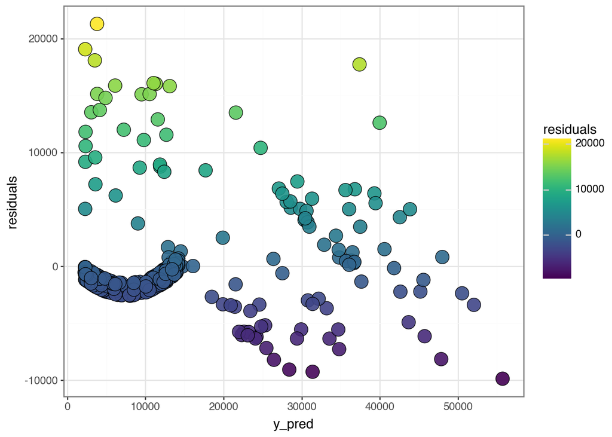

```python
# using residuals and y_pred

plot_df = pd.DataFrame({'y_pred': y_pred, 'residuals': residuals})
plot_df
from plotnine import *

(ggplot(plot_df, aes(
    x = 'y_pred',
    y = 'residuals',
    fill = 'residuals'))
+ geom_point(size = 6,stroke =0.3, alpha =0.9)
+theme_bw()
)
```

The U shape pattern shows this model is missingsome structure in data, the points are kind of clustered around 0 for y_pred? random scatter around 0 for y_red is a good fit, but the curves shows it may need improvement.